# Assignment 8: Bootstrap Methods and Applications

Matthew Gray

Due: March 31, 2026

## **Assignment Objectives**

- Reinforce the understanding of Bootstrap sampling .
- Understand the bootstrap estimation: confidence interval and sampling distribution.

## **Policies of Using AI Tools**

**Policy on AI Tool Use**: Please adhere to the AI tool policy specified in the course syllabus. The direct copying of AI-generated content is strictly prohibited. All submitted work must reflect your own understanding; where external tools are consulted, content must be thoroughly rephrased and synthesized in your own words.

**Code Inclusion Requirement**: Any code included in your essay must be properly commented to explain the purpose and/or expected output of key code lines. Submitting AI-generated code without meaningful, student-added comments will not be accepted.

**Log-normal Distribution Revisited**

If $Y = \ln(X) \sim N(\mu, \sigma^2)$, then $X$ follows a lognormal distribution $X \sim \text{Lognormal}(\mu, \sigma^2)$. The probability density is given by

$$f(x|\mu,\sigma) = \frac{1}{x\sigma\sqrt{2\pi}} \exp\left(-\frac{(\ln x -
\mu)^2}{2\sigma^2}\right), \quad x > 0$$

After some algebra, we can express the mean and variance of the above lognormal distribution in the following

$$\begin{align}
\mathbb{E}[X] &= \exp\left(\mu + \frac{\sigma^2}{2}\right) \\
\text{Var}(X) &= [\exp(\sigma^2) - 1] \exp(2\mu + \sigma^2)
\end{align}$$

Using the relationship between normal and log-normal distribution and a sample $\{x_1, x_2, \dots, x_n\}$, the MLE estimators of $\mu$ and $\sigma^2$ are given by

$$\begin{align}
\hat{\mu} &= \frac{1}{n}\sum_{i=1}^n \ln(x_i) \\
\hat{\sigma}^2 &= \frac{1}{n}\sum_{i=1}^n (\ln(x_i) - \hat{\mu})^2
\end{align}$$

Using the plug-in principle of MLE, we have the MLE of $\mathbb{E}[X]$ and $\text{Var}(X)$ in the following

$$\boxed{\widehat{\mathbb{E}[X]} = \exp\left(\hat{\mu} +
\frac{\hat{\sigma}^2}{2}\right)}$$

**This assignment focuses on constructing various bootstrap confidence intervals of the lognormal population mean $\mathbb{E}[X]$**

## **Question: Trace Metal Concentrations in Soil**

Soil lead (Pb) concentrations (mg/kg) from 55 urban garden sites. Trace metals in environmental media typically follow lognormal distributions due to:

- Multiplicative processes controlling accumulation
- Positive constraints (concentrations cannot be negative)
- Right-skewed nature of contamination patterns

```
0.85, 1.23, 0.92, 3.45, 2.11, 1.56, 4.89, 2.34, 1.78, 6.72, 0.95, 1.34, 8.91,
2.67, 1.89, 5.43, 1.12, 3.78, 2.45, 7.65, 1.05, 1.45, 12.34, 2.89, 2.01, 4.56,
1.23, 4.32, 2.67, 9.87, 0.99, 1.56, 15.23, 3.12, 2.34, 3.89, 1.34, 5.67, 2.89,
11.45, 1.12, 1.67, 18.90, 3.45, 2.56, 3.45, 1.45, 6.78, 3.12, 14.56, 1.23, 1.78,
22.34, 3.78, 2.78
```

$$\boxed{\text{Instructions:}}$$

Assume the data follow a log-normal distribution. For each question in parts (b)–(d), begin by clearly explaining the reasoning behind your analytical approach. Then, develop your own R functions to implement three types of confidence intervals: the asymptotic interval, the percentile bootstrap interval, and the bias-corrected and accelerated (BCa) bootstrap interval. Use these functions to construct the required confidence intervals, and verify your results using the appropriate functions from the `boot` package.

You are encouraged to design a wrapper function that integrates all confidence interval methods, allowing users to select the desired method through an input argument.

$$\boxed{\text{Individual
Questions:}}$$

```r
library(boot)
```

a). Perform 5000 bootstrap samples to estimate the bootstrap sampling distribution of $\boxed{\widehat{\mathbb{E}[X]}}$. Display the distribution using either a histogram or a kernel density plot. Comment on the shape, variability, and any notable patterns observed in the bootstrap sampling distribution.

```r
# --------------- STORING SAMPLE DATA ---------------------------------------------------------------------------
lead_sample <- c(0.85, 1.23, 0.92, 3.45, 2.11, 1.56, 4.89, 2.34, 1.78, 6.72, 0.95, 1.34, 8.91,
2.67, 1.89, 5.43, 1.12, 3.78, 2.45, 7.65, 1.05, 1.45, 12.34, 2.89, 2.01, 4.56,
1.23, 4.32, 2.67, 9.87, 0.99, 1.56, 15.23, 3.12, 2.34, 3.89, 1.34, 5.67, 2.89,
11.45, 1.12, 1.67, 18.90, 3.45, 2.56, 3.45, 1.45, 6.78, 3.12, 14.56, 1.23, 1.78,
22.34, 3.78, 2.78)
# lead_sample: store sample lead concentration measurements as a vector
```

```r
# -----------------DEFINING THE BOOTSTRAP FUNCTION -----------------------------------------------------------------------
bootstrap_expectations <- function(data, B)
# bootstrap_expectations: function with two arguments
# data: the random sample from the population with which you will make bootstrap samples
# B: the number of bootstrap samples you plan to create
{
# this bracket begins the definition of the function
n <- length(data)
# n: the number of observations in your random sample
t_obs_mean_mle <- 1/n * sum(log(data))
t_obs_var_mle <- 1/n * sum((log(data)-t_obs_mean_mle)^2)
t_obs_expectation <- exp(t_obs_mean_mle + t_obs_var_mle/2)
# t_obs: the computed statistic for your original random sample. This only needs to be computed once.
# t_obs_mean_mle and t_obs_var_mle are used to construct t_obs_expectation
# t_obs_expectation will not become part of your bootstrap distribution. This is your actual estimate from the real world.
boot_expectation <- numeric(B)
# boot_expectation: empty vector of length B that will eventually store all the bootstrap statistics you will compute

for (b in 1:B)
{
# everything inside of this bracket will loop B times, filling the vector boot_expectation
indices <- sample(1:n, n, replace = TRUE)
# the sample function samples with replacement from the vector 1:n (the integers 1,2,3, ... n) until sample size is n
# the result is a vector called indices which stores the position of data values we'd like in our bootstrap sample
bootstrap_sample <- data[indices]
# we index our data with the indices vector to create our bootstrap sample
boot_mean_mle <- 1/n * sum(log(bootstrap_sample))
boot_var_mle <- 1/n * sum((log(bootstrap_sample)-boot_mean_mle)^2)
boot_expectation[b] <- exp(boot_mean_mle + boot_var_mle/2)
# we compute the expectation of our bootstrap sample
# and then feed that value into our bootstrap distribution vector, filling in position b
}
# everything after this bracket is outside the loop

return(list(observed_expectation = t_obs_expectation, distribution_expectation = boot_expectation))
# save all of our data in a list
}
# this bracket ends the definition of the function
```

```r
# ----------------- CREATING OUR BOOTSTRAP ESTIMATES -----------------------------------------------------------------------
boot_expect <- bootstrap_expectations(lead_sample,5000)
# boot_expect: a list of 5000 bootstrap expectations, as well as the observed expectation estimate from the sample data.

bootstrap_estimates <- boot_expect$distribution_expectation
# Extract the bootstrap expectations into a vector called bootstrap estimates

obs_estimate <- boot_expect$observed_expectation
# Extract the observed expectation into a vector called bootstrap estimates
```

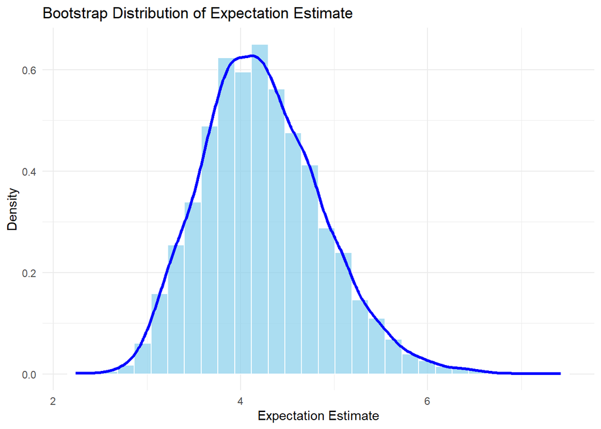

```r
# ----------------- GRAPHING BOOTSTRAP ESTIMATE DISTRIBUTION -----------------------------------------------------------------------
df_expect <- data.frame(expect_hat = bootstrap_estimates)
# df_expect: ggplot cannot take vectors, so we need to create a data frame to give it

p_expect <- ggplot(df_expect, aes(x = expect_hat)) +
geom_histogram(aes(y = ..density..), bins = 30, fill = "skyblue", color = "white", alpha = 0.7) +
geom_density(kernel = "gaussian", color = "blue", linewidth = 1.2) +
labs(
title = "Bootstrap Distribution of Expectation Estimate",
x = "Expectation Estimate",
y = "Density"
) +
theme_minimal()
p_expect
```

**Answer:**

The bootstrap sampling distribution of the expectation is right‑skewed. This makes sense given the heavy‑tailed nature of the lognormal model from which the sample was drawn and the fact that expectations are very sensitive to large values.

b). Construct a 95% bootstrap percentile confidence interval for $\mu_{LN} = \mathbb{E}[X]$.

**Process:**

Compute bootstrap lognormal means from the sample and store them in a vector. Find the 2.5th and 97.5th percentiles of that vector (alpha/2, 1 - alpha/2). Output those percentiles as the lower and upper bounds of our confidence interval.

```r
# ----------------- BOOTSTRAP PERCENTILE CONFIDENCE INTERVAL FUNCTION ----------------------------------------
percentile_ci <- function(data, statistic, B=5000, alpha = 0.05)
# percentile_ci: function with four arguments
# data: the random sample from the population with which you will make bootstrap samples
# statistic: the statistic you will compute to create your bootstrap estimates
# B: the number of bootstrap samples you plan to create
# alpha: significance level (default 0.05 for a 95% CI)
{
# this bracket begins the definition of the function

n <- length(data)
# n: the number of observations in your random sample
boot_dist <- numeric(B)
# boot_dist: empty vector of length B that will eventually store all the bootstrap statistics you will compute

for (b in 1:B)
{
# everything inside of this bracket will loop B times, filling the vector boot_expectation
indices <- sample(1:n, n, replace = TRUE)
# the sample function samples with replacement from the vector 1:n (the integers 1,2,3, ... n) until sample size is n
# the result is a vector called indices which stores the position of data values we'd like in our bootstrap sample
boot_sample <- data[indices]
# we index our data with the indices vector to create our bootstrap sample
boot_dist[b] <- statistic(boot_sample)
# we compute the statistic of our bootstrap sample. (We add statistic as an argument to make the code more reusable.)
# and then feed that value into our bootstrap distribution vector, filling in position b
}
# everything after this bracket is outside the loop

sorted_boot <- sort(boot_dist)
# Sort the bootstrap distribution

lower_prob <- alpha / 2
# Compute lower percentile position (example .025 for a 95% CI)
upper_prob <- 1 - alpha / 2
# Compute upper percentile position (example .975 for a 95% CI)

lower <- quantile(sorted_boot, probs = lower_prob)
# Extract lower bound percentile from the sorted distribution
upper <- quantile(sorted_boot, probs = upper_prob)
# Extract upper bound percentile from the sorted distribution

return(c(lower = lower, upper = upper))
# Return the interval
}
# this bracket ends the definition of the function

# ----------------- DEFINE STATISTIC: LOGNORMAL EXPECTATION ---------------------------------------------------------
lognormal_expectation <- function(x) {
  m <- mean(log(x))
  v <- mean((log(x) - m)^2)
  exp(m + v/2) }

# ----------------- CALL FUNCTION -------------------------------------------------------------------------
percentile_ci(lead_sample, lognormal_expectation, B = 5000, alpha = 0.05)
```

```
 lower.2.5% upper.97.5%
   3.143243    5.594888
```

c). Construct a 95% bootstrap BCa confidence interval for $\mu_{LN} = \mathbb{E}[X]$.

**Process:**

Compute bootstrap lognormal means from the sample and store them in a vector. Compute the observed lognormal mean from the original sample. Convert the proportion of bootstrap estimates below the observed statistic into a z-score. This is the bias-correction term. Compute jackknife lognormal means from the sample and store them in a vector. Compute the acceleration constant. Compute the adjusted percentiles and output them as the bounds of our confidence interval.

```r
# ----------------- BOOTSTRAP BCa CONFIDENCE INTERVAL FUNCTION ---------------------------------------------------------
bca_ci <- function(data, statistic, B=5000, alpha = 0.05)
# bca_ci: function with four arguments
# data: the random sample from the population with which you will make bootstrap and jackknife samples
# statistic: the statistic you will compute to create your bootstrap and jackknife estimates
# B: the number of bootstrap samples you plan to create
# alpha: significance level (default 0.05 for a 95% CI)
{
# this bracket begins the definition of the function

n <- length(data)
# n: the number of observations in your random sample
boot_dist <- numeric(B)
# boot_dist: empty vector of length B that will eventually store all the bootstrap statistics you will compute

for (b in 1:B)
{
# everything inside of this bracket will loop B times, filling the vector boot_expectation
indices <- sample(1:n, n, replace = TRUE)
# the sample function samples with replacement from the vector 1:n (the integers 1,2,3, ... n) until sample size is n
# the result is a vector called indices which stores the position of data values we'd like in our bootstrap sample
boot_sample <- data[indices]
# we index our data with the indices vector to create our bootstrap sample
boot_dist[b] <- statistic(boot_sample)
# we compute the statistic of our bootstrap sample. (We add statistic as an argument to make the code more reusable.)
# and then feed that value into our bootstrap distribution vector, filling in position b
}
# everything after this bracket is outside the loop

theta_hat <- statistic(data)
# theta_hat: compute the statistic of our original sample

# ----- Bias correction -----
prop_less <- mean(boot_dist < theta_hat)
# prop_less: # of bootstrap expectations that are less than the observed expectation divided by # of bootstrap estimates
z0 <- qnorm(prop_less)
# z0: converts the proportion of bootstrap estimates below the observed statistic into a z-score
# This is the bias-correction term in the BCa method.

# ----- Acceleration via jackknife -----
jack_vals <- numeric(n)
# jack_vals: empty vector of length n (your sample size) that will eventually store all jackknife estimates
for (i in 1:n)
{
# everything inside of this bracket will loop n times, filling the vector jack_vals
jack_sample <- data[-i]
# jack_sample: drop the i-th observation from your sample and store all other observations here (leave one out method)
jack_vals[i] <- statistic(jack_sample)
# we compute the statistic of our jackknife sample. (We add statistic as an argument to make the code more reusable.)
# and then feed that value into our jack_vals vector, filling in position i
}
# everything after this bracket is outside the loop

# --- Intermediary computation to create adjusted percentiles -----
theta_jack_mean <- mean(jack_vals)
numerator <- sum((theta_jack_mean - jack_vals)^3)
denominator <- sum((theta_jack_mean - jack_vals)^2)
a_hat <- numerator / (6 * denominator^(3/2))
# a_hat: the acceleration constant for the BCa method
# measures skewness in the jackknife distribution of the statistic
z_alpha <- qnorm(alpha / 2)
# z_alpha: z-score corresponding to the lower tail probability alpha/2
z_1alpha <- qnorm(1 - alpha / 2)
# z_1alpha: z-score corresponding to the upper tail probability 1 - alpha/2

# ----- Adjusted percentiles -----
alpha1 <- pnorm(z0 + (z0 + z_alpha) / (1 - a_hat * (z0 + z_alpha)))
alpha2 <- pnorm(z0 + (z0 + z_1alpha) / (1 - a_hat * (z0 + z_1alpha)))
# alpha1, alpha2: adjusted percentile cutoffs for the BCa interval
# incorporates both bias correction (z0) and acceleration (a_hat)

# ----- Extract BCa interval -----
lower <- quantile(boot_dist, probs = alpha1)
upper <- quantile(boot_dist, probs = alpha2)

return(c(lower = lower, upper = upper))
# Return the interval(use this if not verifying with boot.ci)
}
# this bracket ends the definition of the function

# ----------------- DEFINE STATISTIC: LOGNORMAL EXPECTATION ---------------------------------------------------------
lognormal_expectation <- function(x) {
  m <- mean(log(x))
  v <- mean((log(x) - m)^2)
  exp(m + v/2) }

# ----------------- CALL FUNCTION -------------------------------------------------------------------------
ci_bca <- bca_ci(lead_sample, lognormal_expectation, B = 5000, alpha = 0.05)
ci_bca
```

```
lower.3.686487% upper.98.45712%
       3.184434        5.762887
```

d). Use the Central Limit Theorem to construct a 95% asymptotic confidence interval for $\mu_{LN} = \mathbb{E}[X]$.

**Process:**

Compute bootstrap lognormal means from the sample and store them in a vector. Compute the standard deviation of that vector to get standard error of the sampling distribution. Compute the observed lognormal mean from the original sample. Compute the upper-tail standard normal critical value. Compute bounds using the formula observed_estmate +- z * se_boot

```r
# ----------------- BOOTSTRAP ASYMPTOTIC CONFIDENCE INTERVAL FUNCTION -----------------------------
asymptotic_bootstrap_ci <- function(data, statistic, B = 5000, alpha = 0.05)
# asymptotic_bootstrap_ci: function with four arguments
# data: the random sample from the population with which you will make bootstrap samples
# statistic: the statistic you will compute to create your bootstrap estimate
# B: the number of bootstrap samples you plan to create
# alpha: significance level (default 0.05 for a 95% CI)
{
n <- length(data)
# n: the number of observations in your random sample
boot_dist <- numeric(B)
# boot_dist: empty vector of length B that will eventually store all the bootstrap statistics you will compute

for (b in 1:B)
{
# everything inside of this bracket will loop B times, filling the vector boot_expectation
indices <- sample(1:n, n, replace = TRUE)
# the sample function samples with replacement from the vector 1:n (the integers 1,2,3, ... n) until sample size is n
# the result is a vector called indices which stores the position of data values we'd like in our bootstrap sample
boot_sample <- data[indices]
# we index our data with the indices vector to create our bootstrap sample
boot_dist[b] <- statistic(boot_sample)
# we compute the statistic of our bootstrap sample. (We add statistic as an argument to make the code more reusable.)
# and then feed that value into our bootstrap distribution vector, filling in position b
}
# everything after this bracket is outside the loop

se_boot <- sd(boot_dist)
# se_boot: bootstrap standard error

theta_hat <- statistic(data)
# theta_hat: observed statistic

z <- qnorm(1 - alpha/2)
# z: upper-tail standard normal critical value

lower <- theta_hat - z * se_boot
# lower: compute the lower bound of the ci
upper <- theta_hat + z * se_boot
# upper: compute the upper bound of the ci

return(c(lower = lower, upper = upper))
# Return the interval
}
# this bracket ends the definition of the function

# ----------------- DEFINE STATISTIC: LOGNORMAL EXPECTATION ---------------------------------------------------------
lognormal_expectation <- function(x) {
  m <- mean(log(x))
  v <- mean((log(x) - m)^2)
  exp(m + v/2)
}

# ----------------- CALL FUNCTION -------------------------------------------------------------------------
ci_asymptotic <- asymptotic_bootstrap_ci(lead_sample, lognormal_expectation, B = 5000, alpha = 0.05)
ci_asymptotic
```

```
   lower    upper
2.944163 5.492035
```

f). Assuming the confidence intervals constructed in the previous parts are valid, evaluate their performance by comparing their widths, symmetry, stability, and sensitivity to distributional skewness. Then, provide a well‑reasoned recommendation regarding which method is most suitable for this analysis.

**Answer:**

The asymptotic interval is numerically stable once the bootstrap standard error is well estimated, but its statistical stability is weaker under strong skewness because the normal approximation can misrepresent tail behavior. The percentile interval is stable in the sense that it directly mirrors the bootstrap distribution, though it can be influenced by extreme bootstrap replicates. The BCa interval is somewhat more computationally involved—requiring both bootstrap and jackknife steps—but tends to be more stable for coverage accuracy, especially when the sampling distribution is asymmetric.

The asymptotic interval is always symmetric by construction, making it poorly suited for skewed distributions. In contrast, both the percentile and BCa intervals are asymmetric, with longer upper tails that reflect the true shape of the bootstrap distribution. The BCa method goes further by explicitly correcting for both bias and skewness through its bias‑correction and acceleration terms. This produces endpoints that more accurately track the underlying sampling distribution, which is especially important when the statistic is influenced by extreme values, as is the case with the lognormal mean.

**———————- Wrapper Function ———————————————————————————**

```r
# ----------------- WRAPPER FUNCTION FOR ALL CI TYPES -----------------------------
bootstrap_ci <- function(data, statistic, B = 5000, alpha = 0.05, type = c("percentile", "bca", "asymptotic"))
{
# Match the CI type argument
type <- match.arg(type)

# Dispatch to the appropriate CI function
  if (type == "percentile") {
    return(percentile_ci(data, statistic, B, alpha))
  }

  if (type == "bca") {
    return(bca_ci(data, statistic, B, alpha))
  }

  if (type == "asymptotic") {
    return(asymptotic_bootstrap_ci(data, statistic, B, alpha))
  }
}

# ----------------- HOW TO CALL FUNCTIONS --------------------------------------------------------------------
# bootstrap_ci(lead_sample, lognormal_expectation, B = 5000, alpha = 0.05, type = "percentile")
# bootstrap_ci(lead_sample, lognormal_expectation, B = 5000, alpha = 0.05, type = "bca")
# bootstrap_ci(lead_sample, lognormal_expectation, B = 5000, alpha = 0.05, type = "asymptotic")
```

**———————- Verification: reproduce this assignment using built-in boot functions in R ———————-**

**Notes:**

My confidence intervals and the ones created with boot.ci are reasonably close. The underlying bootstrap distributions fed through the algorithms are different, thus the intervals are subject to randomness and therefore do not match exactly.

```r
lognormal_expectation_boot <- function(data, indices) {
  x <- data[indices]
  m <- mean(log(x))
  v <- mean((log(x) - m)^2)
  exp(m + v/2)
}

library(boot)

boot_out <- boot(
  data = lead_sample,
  statistic = lognormal_expectation_boot,
  R = 5000
)

boot.ci(boot_out, type = "perc")
```

```
BOOTSTRAP CONFIDENCE INTERVAL CALCULATIONS
Based on 5000 bootstrap replicates

CALL :
boot.ci(boot.out = boot_out, type = "perc")

Intervals :
Level     Percentile
95%   ( 3.095,  5.587 )
Calculations and Intervals on Original Scale
```

```r
boot.ci(boot_out, type = "bca")
```

```
BOOTSTRAP CONFIDENCE INTERVAL CALCULATIONS
Based on 5000 bootstrap replicates

CALL :
boot.ci(boot.out = boot_out, type = "bca")

Intervals :
Level       BCa
95%   ( 3.203,  5.800 )
Calculations and Intervals on Original Scale
```

```r
boot.ci(boot_out, type = "norm")
```

```
BOOTSTRAP CONFIDENCE INTERVAL CALCULATIONS
Based on 5000 bootstrap replicates

CALL :
boot.ci(boot.out = boot_out, type = "norm")

Intervals :
Level      Normal
95%   ( 2.943,  5.459 )
Calculations and Intervals on Original Scale
```